# module 4

Working with the notebook

# import packages

```python
import numpy as np
import pandas as pd
import seaborn as sns
import pandas as pd
from sklearn.linear_model import LinearRegression
from sklearn.metrics import mean_squared_error
import plotly.express as px
```

# dataset

Download the spambase dataset from UCI Machine Learning repository.

## Prepare column names

```python
lines = open('data/spambase.names').readlines()
lines = lines[33:]
colnames = [x.split(':')[0] for x in lines]
colnames.append('spam_class')
len(colnames), colnames[:10]
```

```
(58,
 ['word_freq_make',
  'word_freq_address',
  'word_freq_all',
  'word_freq_3d',
  'word_freq_our',
  'word_freq_over',
  'word_freq_remove',
  'word_freq_internet',
  'word_freq_order',
  'word_freq_mail'])
```

## Read the data

```python
# reading csv files
df =  pd.read_csv('data/spambase.data', sep=",", header = None)
df.columns = colnames
df.head(10).iloc[:,:5]
```

|  | word_freq_make | word_freq_address | word_freq_all | word_freq_3d | word_freq_our |
| --- | --- | --- | --- | --- | --- |
| 0 | 0.00 | 0.64 | 0.64 | 0.0 | 0.32 |
| 1 | 0.21 | 0.28 | 0.50 | 0.0 | 0.14 |
| 2 | 0.06 | 0.00 | 0.71 | 0.0 | 1.23 |
| 3 | 0.00 | 0.00 | 0.00 | 0.0 | 0.63 |
| 4 | 0.00 | 0.00 | 0.00 | 0.0 | 0.63 |
| 5 | 0.00 | 0.00 | 0.00 | 0.0 | 1.85 |
| 6 | 0.00 | 0.00 | 0.00 | 0.0 | 1.92 |
| 7 | 0.00 | 0.00 | 0.00 | 0.0 | 1.88 |
| 8 | 0.15 | 0.00 | 0.46 | 0.0 | 0.61 |
| 9 | 0.06 | 0.12 | 0.77 | 0.0 | 0.19 |

```python
df.shape
```

```
(4601, 58)
```

```python
df_corr = df.corr()
df_corr.head().iloc[:,:5]
```

|  | word_freq_make | word_freq_address | word_freq_all | word_freq_3d | word_freq_our |
| --- | --- | --- | --- | --- | --- |
| word_freq_make | 1.000000 | -0.016759 | 0.065627 | 0.013273 | 0.023119 |
| word_freq_address | -0.016759 | 1.000000 | -0.033526 | -0.006923 | -0.023760 |
| word_freq_all | 0.065627 | -0.033526 | 1.000000 | -0.020246 | 0.077734 |
| word_freq_3d | 0.013273 | -0.006923 | -0.020246 | 1.000000 | 0.003238 |
| word_freq_our | 0.023119 | -0.023760 | 0.077734 | 0.003238 | 1.000000 |

```python
fig = px.imshow(df_corr, text_auto=True)
fig.show()
```

[interactive chart not shown]

# Simple linear regression

Given a dataset of variables $(X_i, Y_i)$ where $X_i$ is the explanatory variable and $Y_i$ is the dependent variable that varies as $X_i$ does, the simplest model that could be applied for the relation between two of them is a linear one. Simple linear regression model is as follows:

$$ Y_i = \beta_0 + \beta_1 X_i + \epsilon_i $$

$\epsilon_i$ - is the random component of the regression handling the residue, i.e. the lag between the estimation and actual value of the dependent parameter.  
$\beta_0$ - constant term or the intercept  
$\beta_1$ - coefficient term or slope of the intercept line

**Loss function**  
Mean squared error

$$MSE=\frac{1}{n}\sum_{i=1}^{n}(Y_i-\hat{Y_i})^2$$

$n$ - number of observations  
$\hat{Y_i}$ - predicted value  
$Y_i$ - observed value

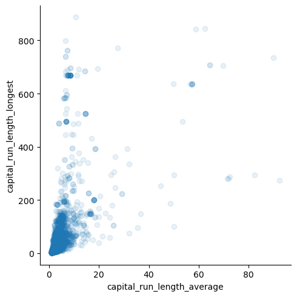

```python
condition = (df['capital_run_length_average'] < 100) & (df['capital_run_length_longest'] < 1000)
sns.lmplot(x='capital_run_length_average',y='capital_run_length_longest',
           data=df[condition],
           fit_reg=False,
          scatter_kws={'alpha':0.1})
```

Correlation

```python
df.corr()['capital_run_length_average']['capital_run_length_longest']
```

```
0.49263829723867375
```

Coefficient of determination $R^{2}$

```python
model.score(x,y)
```

```
0.24269249190622155
```

Mean squared error $MSE$

```python
mean_squared_error(y, y_pred)
```

```
28758.273419688536
```

Coefficient $\beta_1$

```python
model.coef_
```

```
array([3.02592471])
```

Intercept $\beta_0$

```python
model.intercept_
```

```
36.46365470176502
```

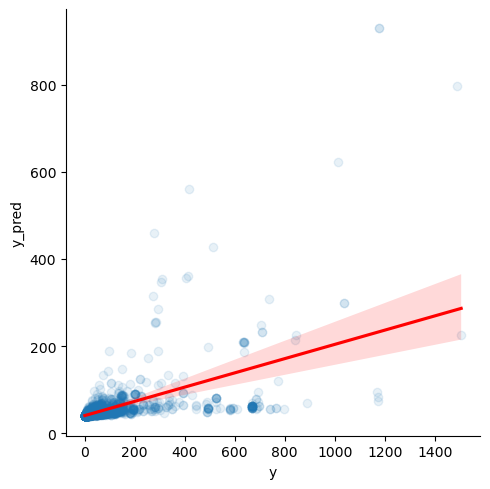

```python
df_vis = pd.DataFrame({'y':y, 'y_pred':y_pred})
df_vis = df_vis.loc[(df_vis['y'] < 2000) & (df_vis['y_pred'] < 1000),:]
sns.lmplot(x='y',y='y_pred',
           data=df_vis,
           fit_reg=True,
           line_kws={'color': 'red'},
          scatter_kws={'alpha':0.1})
```

# R in Python notebook

```python
%reload_ext rpy2.ipython
```

```python
%%R
if (!require('lazyeval')) install.packages('lazyeval',repos='https://cloud.r-project.org/');
```

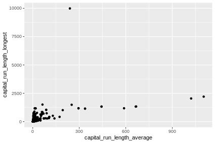

```python
%%R -i df -w 15 -h 10 --units cm

library("ggplot2")

ggplot(df,
       aes(x = capital_run_length_average, y = capital_run_length_longest)) +
geom_point()
```

```python
%%R -i df -o intercept_r -o coef_r -o y_pred_r

model <- lm(capital_run_length_longest ~ capital_run_length_average, data = df)
print(model)

intercept_r <- coef(model)['(Intercept)']
coef_r <- coef(model)['capital_run_length_average']
y_pred_r <- predict(model)
```

```
Call:
lm(formula = capital_run_length_longest ~ capital_run_length_average,
    data = df)

Coefficients:
               (Intercept)  capital_run_length_average
                    36.464                       3.026
```

```python
intercept_r, coef_r
```

```
(array([36.4636547]), array([3.02592471]))
```

```python
y_pred_r
```

```
array([47.8290279 , 51.93823365, 66.18126125, ..., 40.71205299,
       39.93439034, 40.24606059])
```

# Exercises

1. write latex equation for mean absolute error
2. create a table with Markdown with evaluation metrics of our regression model and their values
3. select 2 variables from our dataset you think might correlate and plot their scatterplot with seaborn
4. create a simple regression model of these variables and evaluate it with $R^{2}$ and $MSE$

# References

1. Markdown [cheatsheet](https://www.markdownguide.org/cheat-sheet/)
2. Latex [reference](https://en.wikibooks.org/wiki/LaTeX/Mathematics)
3. Latex machine learning equations [link](https://blmoistawinde.github.io/ml_equations_latex)
4. Simple linear regression [reference](https://en.wikipedia.org/wiki/Simple_linear_regression)
5. rpy2 package [reference](https://rpy2.github.io/doc/v3.5.x/html/introduction.html#)
6. R magic [reference](https://ipython.org/ipython-doc/2/config/extensions/rmagic.html)